# Part I - Prosper Loan Data

## by (Providence Okechukwu)

## Introduction

> This data set contains 113,937 loans with 81 variables on each loan, including loan amount, borrower rate (or interest rate), current loan status, borrower income, and many others.

## Preliminary Wrangling

```python
# import all packages and set plots to be embedded inline
import numpy as np
import pandas as pd
import matplotlib.pyplot as plt
import seaborn as sns

%matplotlib inline
# suppress warnings from final output
import warnings
warnings.simplefilter("ignore")
```

```python
#load my data
data = pd.read_csv("LoanData.csv")
```

```python
pd.set_option('display.max_columns', 500)
pd.set_option('display.max_rows', 500)
data.head()
```

|  | ListingKey | ListingNumber | ListingCreationDate | CreditGrade | Term | LoanStatus | ClosedDate | BorrowerAPR | BorrowerRate | LenderYield | EstimatedEffectiveYield | EstimatedLoss | EstimatedReturn | ProsperRating (numeric) | ProsperRating (Alpha) | ProsperScore | ListingCategory (numeric) | BorrowerState | Occupation | EmploymentStatus | EmploymentStatusDuration | IsBorrowerHomeowner | CurrentlyInGroup | GroupKey | DateCreditPulled | CreditScoreRangeLower | CreditScoreRangeUpper | FirstRecordedCreditLine | CurrentCreditLines | … |
| --- | --- | --- | --- | --- | --- | --- | --- | --- | --- | --- | --- | --- | --- | --- | --- | --- | --- | --- | --- | --- | --- | --- | --- | --- | --- | --- | --- | --- | --- | --- |
| 0 | 1021339766868145413AB3B | 193129 | 2007-08-26 19:09:29.263000000 | C | 36 | Completed | 2009-08-14 00:00:00 | 0.16516 | 0.1580 | 0.1380 | NaN | NaN | NaN | NaN | NaN | NaN | 0 | CO | Other | Self-employed | 2.0 | True | True | NaN | 2007-08-26 18:41:46.780000000 | 640.0 | 659.0 | 2001-10-11 00:00:00 | 5.0 | … |
| 1 | 10273602499503308B223C1 | 1209647 | 2014-02-27 08:28:07.900000000 | NaN | 36 | Current | NaN | 0.12016 | 0.0920 | 0.0820 | 0.07960 | 0.0249 | 0.05470 | 6.0 | A | 7.0 | 2 | CO | Professional | Employed | 44.0 | False | False | NaN | 2014-02-27 08:28:14 | 680.0 | 699.0 | 1996-03-18 00:00:00 | 14.0 | … |
| 2 | 0EE9337825851032864889A | 81716 | 2007-01-05 15:00:47.090000000 | HR | 36 | Completed | 2009-12-17 00:00:00 | 0.28269 | 0.2750 | 0.2400 | NaN | NaN | NaN | NaN | NaN | NaN | 0 | GA | Other | Not available | NaN | False | True | 783C3371218786870A73D20 | 2007-01-02 14:09:10.060000000 | 480.0 | 499.0 | 2002-07-27 00:00:00 | NaN | … |
| 3 | 0EF5356002482715299901A | 658116 | 2012-10-22 11:02:35.010000000 | NaN | 36 | Current | NaN | 0.12528 | 0.0974 | 0.0874 | 0.08490 | 0.0249 | 0.06000 | 6.0 | A | 9.0 | 16 | GA | Skilled Labor | Employed | 113.0 | True | False | NaN | 2012-10-22 11:02:32 | 800.0 | 819.0 | 1983-02-28 00:00:00 | 5.0 | … |
| 4 | 0F023589499656230C5E3E2 | 909464 | 2013-09-14 18:38:39.097000000 | NaN | 36 | Current | NaN | 0.24614 | 0.2085 | 0.1985 | 0.18316 | 0.0925 | 0.09066 | 3.0 | D | 4.0 | 2 | MN | Executive | Employed | 44.0 | True | False | NaN | 2013-09-14 18:38:44 | 680.0 | 699.0 | 2004-02-20 00:00:00 | 19.0 | … |

```python
loandata= data.iloc[:, np.r_[0,1,4,5,7,8,15:20,21,25,26,46:50,63,64,77]]
```

```python
loandata.head()
```

|  | ListingKey | ListingNumber | Term | LoanStatus | BorrowerAPR | BorrowerRate | ProsperScore | ListingCategory (numeric) | BorrowerState | Occupation | EmploymentStatus | IsBorrowerHomeowner | CreditScoreRangeLower | CreditScoreRangeUpper | DebtToIncomeRatio | IncomeRange | IncomeVerifiable | StatedMonthlyIncome | LoanOriginalAmount | LoanOriginationDate | Recommendations |
| --- | --- | --- | --- | --- | --- | --- | --- | --- | --- | --- | --- | --- | --- | --- | --- | --- | --- | --- | --- | --- | --- |
| 0 | 1021339766868145413AB3B | 193129 | 36 | Completed | 0.16516 | 0.1580 | NaN | 0 | CO | Other | Self-employed | True | 640.0 | 659.0 | 0.17 | $25,000-49,999 | True | 3083.333333 | 9425 | 2007-09-12 00:00:00 | 0 |
| 1 | 10273602499503308B223C1 | 1209647 | 36 | Current | 0.12016 | 0.0920 | 7.0 | 2 | CO | Professional | Employed | False | 680.0 | 699.0 | 0.18 | $50,000-74,999 | True | 6125.000000 | 10000 | 2014-03-03 00:00:00 | 0 |
| 2 | 0EE9337825851032864889A | 81716 | 36 | Completed | 0.28269 | 0.2750 | NaN | 0 | GA | Other | Not available | False | 480.0 | 499.0 | 0.06 | Not displayed | True | 2083.333333 | 3001 | 2007-01-17 00:00:00 | 0 |
| 3 | 0EF5356002482715299901A | 658116 | 36 | Current | 0.12528 | 0.0974 | 9.0 | 16 | GA | Skilled Labor | Employed | True | 800.0 | 819.0 | 0.15 | $25,000-49,999 | True | 2875.000000 | 10000 | 2012-11-01 00:00:00 | 0 |
| 4 | 0F023589499656230C5E3E2 | 909464 | 36 | Current | 0.24614 | 0.2085 | 4.0 | 2 | MN | Executive | Employed | True | 680.0 | 699.0 | 0.26 | $100,000+ | True | 9583.333333 | 15000 | 2013-09-20 00:00:00 | 0 |

```python
print(loandata.shape)
print(loandata.info())
```

```
(113937, 21)
<class 'pandas.core.frame.DataFrame'>
RangeIndex: 113937 entries, 0 to 113936
Data columns (total 21 columns):
 #   Column                     Non-Null Count   Dtype
---  ------                     --------------   -----
 0   ListingKey                 113937 non-null  object
 1   ListingNumber              113937 non-null  int64
 2   Term                       113937 non-null  int64
 3   LoanStatus                 113937 non-null  object
 4   BorrowerAPR                113912 non-null  float64
 5   BorrowerRate               113937 non-null  float64
 6   ProsperScore               84853 non-null   float64
 7   ListingCategory (numeric)  113937 non-null  int64
 8   BorrowerState              108422 non-null  object
 9   Occupation                 110349 non-null  object
 10  EmploymentStatus           111682 non-null  object
 11  IsBorrowerHomeowner        113937 non-null  bool
 12  CreditScoreRangeLower      113346 non-null  float64
 13  CreditScoreRangeUpper      113346 non-null  float64
 14  DebtToIncomeRatio          105383 non-null  float64
 15  IncomeRange                113937 non-null  object
 16  IncomeVerifiable           113937 non-null  bool
 17  StatedMonthlyIncome        113937 non-null  float64
 18  LoanOriginalAmount         113937 non-null  int64
 19  LoanOriginationDate        113937 non-null  object
 20  Recommendations            113937 non-null  int64
dtypes: bool(2), float64(7), int64(5), object(7)
memory usage: 16.7+ MB
None
```

```python
loandata.duplicated().sum()
```

```
0
```

```python
loandata.isna().sum()
```

```
ListingKey                       0
ListingNumber                    0
Term                             0
LoanStatus                       0
BorrowerAPR                     25
BorrowerRate                     0
ProsperScore                 29084
ListingCategory (numeric)        0
BorrowerState                 5515
Occupation                    3588
EmploymentStatus              2255
IsBorrowerHomeowner              0
CreditScoreRangeLower          591
CreditScoreRangeUpper          591
DebtToIncomeRatio             8554
IncomeRange                      0
IncomeVerifiable                 0
StatedMonthlyIncome              0
LoanOriginalAmount               0
LoanOriginationDate              0
Recommendations                  0
dtype: int64
```

```python
#drop null values
loandata.dropna(inplace=True)
```

```python
#change the column name for listing category
loandata.rename(columns={'ListingCategory (numeric)' : 'ListingCategory'}, inplace=True)
```

```python
print(loandata['Term'].unique())
print(loandata['LoanStatus'].unique())
print(loandata['ListingCategory'].unique())
print(loandata['EmploymentStatus'].unique())
print(loandata['Occupation'].unique())
print(loandata['LoanOriginationDate'].unique())
```

```
[36 60 12]
['Current' 'Past Due (1-15 days)' 'Defaulted' 'Completed' 'Chargedoff'
 'Past Due (16-30 days)' 'Past Due (61-90 days)' 'Past Due (31-60 days)'
 'Past Due (91-120 days)' 'FinalPaymentInProgress' 'Past Due (>120 days)']
[ 2 16  1  7 13  6 15 20 19 18  8 11  3 14  9 17  0 10  5 12]
['Employed' 'Other' 'Full-time' 'Part-time' 'Retired' 'Self-employed'
 'Not employed']
['Professional' 'Skilled Labor' 'Executive' 'Sales - Retail' 'Laborer'
 'Food Service' 'Fireman' 'Construction' 'Computer Programmer' 'Other'
 'Sales - Commission' 'Retail Management' 'Engineer - Mechanical'
 'Military Enlisted' 'Clerical' 'Teacher' 'Clergy' 'Attorney' 'Nurse (RN)'
 'Accountant/CPA' 'Analyst' 'Flight Attendant' 'Nurse (LPN)'
 'Military Officer' 'Administrative Assistant'
 'Police Officer/Correction Officer' 'Social Worker'
 'Food Service Management' 'Truck Driver' 'Tradesman - Mechanic'
 'Medical Technician' 'Professor' 'Postal Service' 'Waiter/Waitress'
 'Civil Service' 'Pharmacist' 'Tradesman - Electrician' 'Scientist'
 'Dentist' 'Engineer - Electrical' 'Bus Driver' 'Architect'
 'Engineer - Chemical' 'Doctor' 'Chemist' "Teacher's Aide"
 'Pilot - Private/Commercial' "Nurse's Aide" 'Religious'
 'Student - College Senior' 'Principal' 'Investor' 'Psychologist'
 'Realtor' 'Biologist' 'Tradesman - Carpenter' 'Judge' 'Car Dealer'
 'Landscaping' 'Student - College Graduate Student'
 'Student - College Junior' 'Tradesman - Plumber'
 'Student - College Freshman' 'Homemaker' 'Student - Community College'
 'Student - College Sophomore' 'Student - Technical School']
['2014-03-03 00:00:00' '2012-11-01 00:00:00' '2013-09-20 00:00:00' ...
 '2009-07-29 00:00:00' '2009-07-23 00:00:00' '2010-03-02 00:00:00']
```

```python
#convert origination date into datetime datatype
loandata["LoanOriginationDate"] = loandata["LoanOriginationDate"].astype('datetime64[ns]')
```

```python
#separate origination date into year and month

loandata['LoanOriginationYear'] = loandata['LoanOriginationDate'].dt.year
loandata['LoanOriginationMonth']= loandata['LoanOriginationDate'].dt.month
```

```python
loandata['LoanOriginationMonth'].head()
```

```
1     3
3    11
4     9
5    12
6     4
Name: LoanOriginationMonth, dtype: int64
```

```python
#define a function to convert the numeric values for months to first 3 leeters of the month name
def Month_names(x):
    month_dict={1:'Jan', 2:'Feb', 3:'Mar', 4:'Apr', 5:'May', 6:'Jun', 7:'Jul', 8:'Aug', 9:'Sep', 10:'Oct', 11:'Nov', 12:'Dec'}
    return month_dict[x]
```

```python
loandata['LoanOriginationMonth']=loandata['LoanOriginationMonth'].apply(Month_names)
```

```python
cat_var_dict = {'IsBorrowerHomeowner': [True, False],
                    'EmploymentStatus': ['Self-employed', 'Employed', 'Not available', 'Full-time', 'Other',
                                         'Not employed', 'Part-time', 'Retired'],
                    'LoanStatus': ['Completed', 'Current', 'Past Due (1-15 days)', 'Defaulted', 'Chargedoff',
                              'Past Due (16-30 days)','Cancelled','Past Due (61-90 days)', 'Past Due (31-60 days)',
                              'Past Due (91-120 days)','FinalPaymentInProgress','Past Due (>120 days)'],
                    'LoanOriginationMonth': ['Mar', 'Nov', 'Sep', 'Dec', 'Apr', 'May', 'Jan', 'Jul', 'Oct','Feb', 'Jun', 'Aug'],
                    'ProsperScore': [1, 2, 3, 4, 5, 6, 7, 8, 9, 10, 11],
                    'LoanOriginationYear': [2009, 2010, 2011, 2012, 2013, 2014],
                    'IncomeRange' : ['Not displayed', 'Not employed', '$0', '$1-24,999', '$25,000-49,999', '$50,000-74,999',
                                   '$75,000-99,999','$100,000+']}

for var in cat_var_dict:
    cat_var = pd.api.types.CategoricalDtype(ordered = True, categories = cat_var_dict[var])
    loandata[var] = loandata[var].astype(cat_var)
```

```python
loandata.info()
```

```
<class 'pandas.core.frame.DataFrame'>
Int64Index: 76224 entries, 1 to 113936
Data columns (total 23 columns):
 #   Column                 Non-Null Count  Dtype
---  ------                 --------------  -----
 0   ListingKey             76224 non-null  object
 1   ListingNumber          76224 non-null  int64
 2   Term                   76224 non-null  int64
 3   LoanStatus             76224 non-null  category
 4   BorrowerAPR            76224 non-null  float64
 5   BorrowerRate           76224 non-null  float64
 6   ProsperScore           76224 non-null  category
 7   ListingCategory        76224 non-null  int64
 8   BorrowerState          76224 non-null  object
 9   Occupation             76224 non-null  object
 10  EmploymentStatus       76224 non-null  category
 11  IsBorrowerHomeowner    76224 non-null  category
 12  CreditScoreRangeLower  76224 non-null  float64
 13  CreditScoreRangeUpper  76224 non-null  float64
 14  DebtToIncomeRatio      76224 non-null  float64
 15  IncomeRange            76224 non-null  category
 16  IncomeVerifiable       76224 non-null  bool
 17  StatedMonthlyIncome    76224 non-null  float64
 18  LoanOriginalAmount     76224 non-null  int64
 19  LoanOriginationDate    76224 non-null  datetime64[ns]
 20  Recommendations        76224 non-null  int64
 21  LoanOriginationYear    76224 non-null  category
 22  LoanOriginationMonth   76224 non-null  category
dtypes: bool(1), category(7), datetime64[ns](1), float64(6), int64(5), object(3)
memory usage: 9.9+ MB
```

```python
loandata.drop('LoanOriginationDate', 1, inplace=True)
```

```python
loandata.sample(5)
```

|  | ListingKey | ListingNumber | Term | LoanStatus | BorrowerAPR | BorrowerRate | ProsperScore | ListingCategory | BorrowerState | Occupation | EmploymentStatus | IsBorrowerHomeowner | CreditScoreRangeLower | CreditScoreRangeUpper | DebtToIncomeRatio | IncomeRange | IncomeVerifiable | StatedMonthlyIncome | LoanOriginalAmount | Recommendations | LoanOriginationYear | LoanOriginationMonth |
| --- | --- | --- | --- | --- | --- | --- | --- | --- | --- | --- | --- | --- | --- | --- | --- | --- | --- | --- | --- | --- | --- | --- |
| 15872 | 8BB83580907351981DCD214 | 794096 | 60 | Current | 0.20593 | 0.1819 | 6 | 1 | CA | Professional | Employed | True | 720.0 | 739.0 | 0.26 | $75,000-99,999 | True | 6416.666667 | 25000 | 0 | 2013 | Jun |
| 19146 | 031935883794061470A5BEA | 898599 | 36 | Current | 0.20268 | 0.1660 | 7 | 3 | NE | Truck Driver | Employed | False | 720.0 | 739.0 | 0.36 | $75,000-99,999 | True | 6750.000000 | 13000 | 0 | 2013 | Sep |
| 85140 | F2C43457430343592A80599 | 417527 | 36 | Completed | 0.28584 | 0.2600 | 8 | 1 | MO | Other | Full-time | True | 660.0 | 679.0 | 0.27 | $25,000-49,999 | True | 3198.000000 | 1500 | 0 | 2009 | Aug |
| 13905 | 661535993032093447FA1BA | 1146827 | 36 | Current | 0.25279 | 0.2150 | 4 | 2 | OR | Executive | Employed | True | 660.0 | 679.0 | 0.31 | $75,000-99,999 | True | 7083.333333 | 5000 | 0 | 2014 | Jan |
| 54833 | 7BF5359579384717041A639 | 1020751 | 36 | Current | 0.17969 | 0.1435 | 8 | 1 | CA | Engineer - Electrical | Employed | True | 680.0 | 699.0 | 0.39 | $50,000-74,999 | True | 5333.333333 | 9000 | 0 | 2014 | Jan |

```python
loandata.info()
```

```
<class 'pandas.core.frame.DataFrame'>
Int64Index: 76224 entries, 1 to 113936
Data columns (total 22 columns):
 #   Column                 Non-Null Count  Dtype
---  ------                 --------------  -----
 0   ListingKey             76224 non-null  object
 1   ListingNumber          76224 non-null  int64
 2   Term                   76224 non-null  int64
 3   LoanStatus             76224 non-null  category
 4   BorrowerAPR            76224 non-null  float64
 5   BorrowerRate           76224 non-null  float64
 6   ProsperScore           76224 non-null  category
 7   ListingCategory        76224 non-null  int64
 8   BorrowerState          76224 non-null  object
 9   Occupation             76224 non-null  object
 10  EmploymentStatus       76224 non-null  category
 11  IsBorrowerHomeowner    76224 non-null  category
 12  CreditScoreRangeLower  76224 non-null  float64
 13  CreditScoreRangeUpper  76224 non-null  float64
 14  DebtToIncomeRatio      76224 non-null  float64
 15  IncomeRange            76224 non-null  category
 16  IncomeVerifiable       76224 non-null  bool
 17  StatedMonthlyIncome    76224 non-null  float64
 18  LoanOriginalAmount     76224 non-null  int64
 19  Recommendations        76224 non-null  int64
 20  LoanOriginationYear    76224 non-null  category
 21  LoanOriginationMonth   76224 non-null  category
dtypes: bool(1), category(7), float64(6), int64(5), object(3)
memory usage: 9.3+ MB
```

```python
loandata.to_csv('loandata_cleaned.csv', index=False)
```

### What is the structure of your dataset?

> The original dataset contained 113937 records and 81 variables but my cleaned dataset contains 76224 loan records with 22 variables. Most variables are numeric in nature while the rest are of object, categorical and bool type.

The variables includes:

- ListingKey: Unique key for each listing
- ListingNumber: The number that uniquely identifies the listing to the public as displayed on the website.
- Term: The length of the loan expressed in months.
- LoanStatus: The current status of the loan: Cancelled, Chargedoff, Completed, Current, Defaulted, FinalPaymentInProgress, .
- BorrowerAPR: The Borrower's Annual Percentage Rate (APR) for the loan.
- BorrowerRate: The Borrower's interest rate for this loan.
- ProsperScore: A custom risk score built using historical Prosper data. The score ranges from 1-10, with 10 being the best, or lowest risk score. Applicable for loans originated after July 2009.
- Listing_category: The category of the listing that the borrower selected when posting their listing
- Occupation: The Occupation selected by the Borrower at the time they created the listing.
- EmploymentStatus:The employment status of the borrower at the time they posted the listing.
- IsBorrowerHomeowner: A Borrower will be classified as a homowner if they have a mortgage on their credit profile or provide documentation confirming they are a homeowner.
- CreditScoreRangeLower: The lower value of the credit score range of borrower provided by credit agency
- CreditScoreRangeUpper: The upper value of the credit score range of borrower provided by credit agency
- DebtToIncomeRatio: debt/income. capped at 10.01
- IncomeRange: The income range of the borrower at the time the listing was created.
- IncomeVerifiable: Borrower provided documents to prove income
- LoanOriginalAmount: The origination amount of the loan.
- BorrowerState: The two letter abbreviation of the state of the address of the borrower at the time the Listing was created.
- StatedMonthlyIncome:The monthly income the borrower stated at the time the listing was created.
- Recommendations: Number of recommendations the borrower had at the time of listing
- LoanOriginationYear: The date the loan was originated
- LoanOriginationMonth: The Month the loan was originated.

### What is/are the main feature(s) of interest in your dataset?

> What variables best affects the population of granted loans.

### What features in the dataset do you think will help support your investigation into your feature(s) of interest?

> I expect that the Listing Category and Credit Score should have the greatest effects. Other variables of interest are Term and Monthly Income.

## Univariate Exploration

I'll start by looking at the listing categories and how the loans are distributed across the categories. What categories are considered for loans the most?

```python
#this is a dictionary of the categories to help decode the meaning of each number
category_dict=  {0:'Not Available', 1 : 'Debt Consolidation', 2 : 'Home Improvement', 3 : 'Business', 4 : 'Personal Loan', 5 : 'Student Use', 6 : 'Auto', 7: 'Other', 8 : 'Baby&Adoption', 9 : 'Boat', 10 : 'Cosmetic Procedure', 11 : 'Engagement Ring', 12 : 'Green Loans', 13 : 'Household Expenses', 14 : 'Large Purchases', 15 : 'Medical/Dental', 16 : 'Motorcycle', 17 : 'RV', 18 : 'Taxes', 19 : 'Vacation', 20 : 'Wedding Loans'}
```

```python
x=list(category_dict.keys())
y=list(category_dict.values())
```

[output not shown]

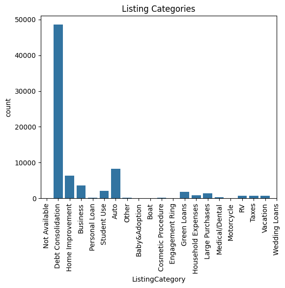

```python
ax= plt.axes([.125, .125, .750, .775])

base_color= sns.color_palette()[0]
sns.countplot(data= loandata, x= 'ListingCategory',  color=base_color);
plt.xticks(x,y, rotation= 90)
plt.title('Listing Categories');
```

From the graph, we can see that majority of the loans were granted to those who needed it for debt consolidation.

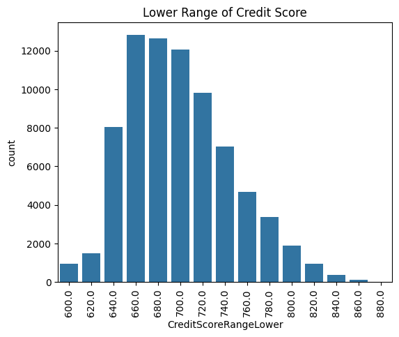

```python
ax= plt.axes([.125, .125, .750, .775])

base_color= sns.color_palette()[0]

list_order= loandata['CreditScoreRangeLower'].value_counts().index
plt.xticks(rotation=90)
sns.countplot(data= loandata, x= 'CreditScoreRangeLower', color=base_color);
plt.title('Lower Range of Credit Score');
```

Now let's check out the upper range of the credit score

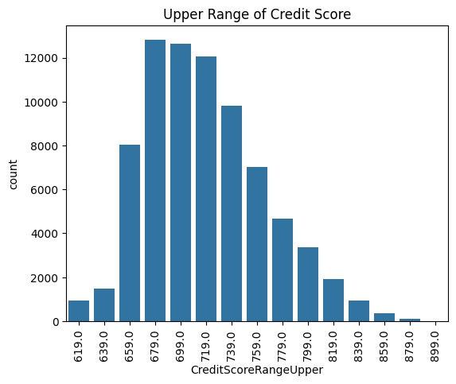

```python
ax= plt.axes([.125, .125, .750, .775])

base_color= sns.color_palette()[0]

list_order= loandata['CreditScoreRangeUpper'].value_counts().index
plt.xticks(rotation=90)
sns.countplot(data= loandata, x= 'CreditScoreRangeUpper', color=base_color);
plt.title('Upper Range of Credit Score');
```

As expected, this is very similar to the lower range distribution with the values of the upper range replacing those of the lower range

Picking the single highest occuring range, we can see that the most frequent range was between 660 and 679. With this credit score, there's a very high chance of being granted a loan

Is having a recommendation important to get a loan?

```python
loandata['Recommendations'].value_counts()
```

```
0     75196
1       875
2       129
3        16
5         2
4         2
18        2
19        1
9         1
Name: Recommendations, dtype: int64
```

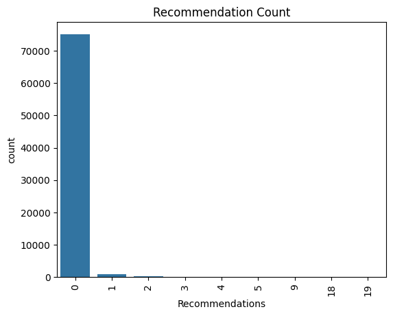

```python
ax= plt.axes([.125, .125, .750, .775])

base_color= sns.color_palette()[0]

list_order= loandata['Recommendations'].value_counts().index
plt.xticks(rotation=90)
sns.countplot(data= loandata, x= 'Recommendations', color=base_color);
plt.title('Recommendation Count');
```

This shows that having recommendations were not paramount to getting the loans.

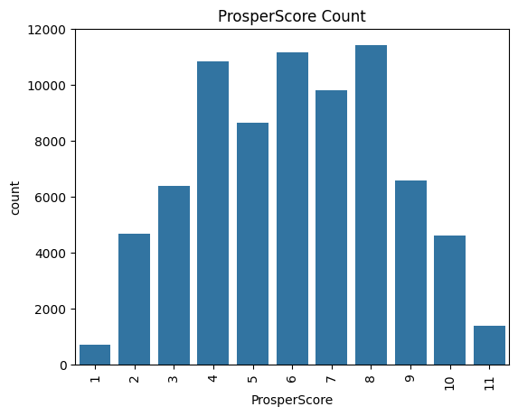

```python
ax= plt.axes([.125, .125, .750, .775])

base_color= sns.color_palette()[0]

list_order= loandata['ProsperScore'].value_counts().index
plt.xticks(rotation=90)
sns.countplot(data= loandata, x= 'ProsperScore', color=base_color);
plt.title('ProsperScore Count');
```

The typical ProsperScore were in the mid range. Majority of the borrowers had a mid ranged ProsperScore.

What is the employment status of an average borrower?

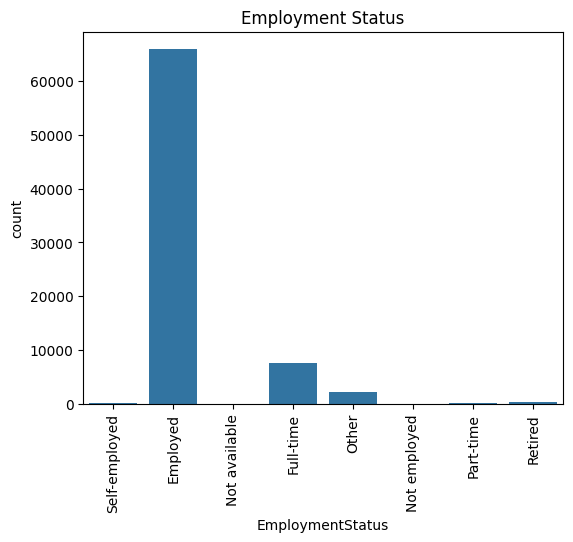

```python
ax= plt.axes([.125, .125, .750, .775])

base_color= sns.color_palette()[0]

list_order= loandata['EmploymentStatus'].value_counts().index
plt.xticks(rotation=90)
sns.countplot(data= loandata, x= 'EmploymentStatus', color=base_color);
plt.title('Employment Status');
```

Majority of the borrowers were employed people.

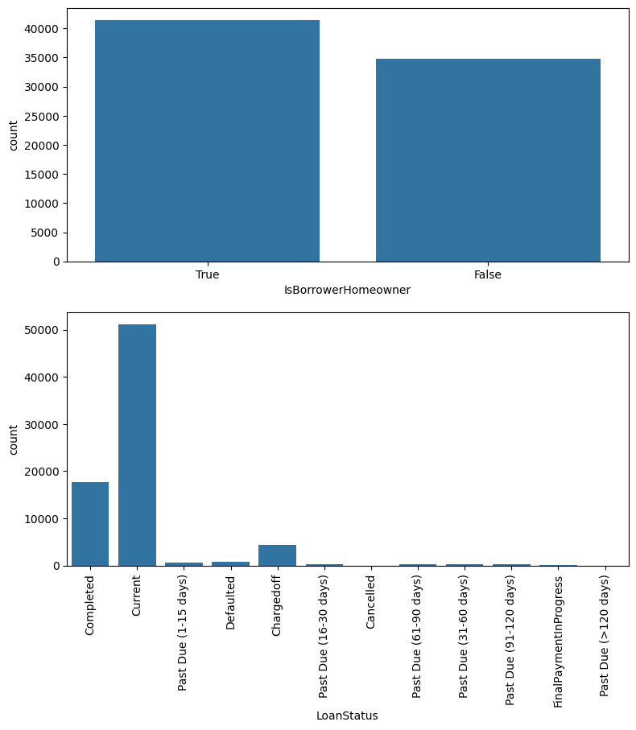

```python
# let's plot all three together to get an idea of each nominal variable's distribution
fig, ax = plt.subplots(nrows=2, figsize = [9,9])

default_color = sns.color_palette()[0]
sns.countplot(data = loandata, x = 'IsBorrowerHomeowner', color = default_color, ax = ax[0])
sns.countplot(data = loandata, x = 'LoanStatus', color = default_color, ax = ax[1])
plt.xticks(rotation=90)

plt.show()
```

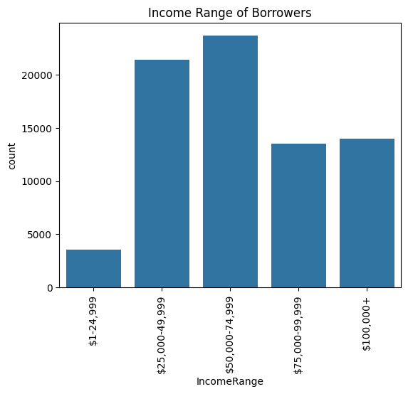

```python
#plot the income range of the borrowers
ax= plt.axes([.125, .125, .750, .775])

base_color= sns.color_palette()[0]

list_order= loandata['IncomeRange'].value_counts().index
plt.xticks(rotation=90)
sns.countplot(data= loandata, x= 'IncomeRange', color=base_color);
plt.title('Income Range of Borrowers');
plt.xlim(2.5);
```

Most borrowers are averagely earned people who are home owner and have a current status loan of current.

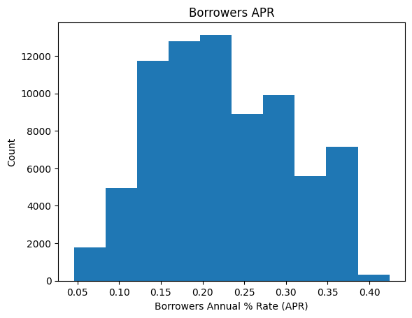

```python
# A simple histogram plot of the variable BorrowerAPR
plt.hist(data=loandata, x='BorrowerAPR');
plt.xlabel('Borrowers Annual % Rate (APR)');
plt.ylabel('Count');
plt.title('Borrowers APR');
```

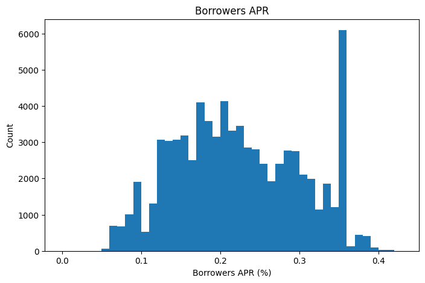

```python
#further investigation on smaller bin size
binsize = 0.01
bins = np.arange(0, loandata['BorrowerAPR'].max()+binsize, binsize)
plt.figure(figsize=[8, 5])
plt.hist(data = loandata, x = 'BorrowerAPR', bins = bins)
plt.xlabel('Borrowers APR (%)')
plt.ylabel('Count')
plt.title('Borrowers APR')
plt.show()
```

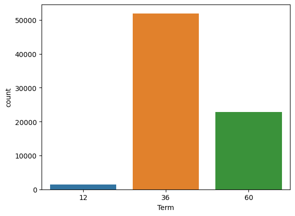

```python
sns.countplot(data=loandata, x='Term');
```

The 36 months term was more popular among the loans.

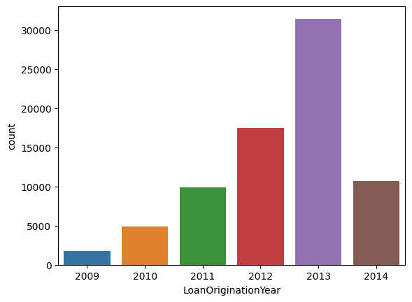

```python
sns.countplot(data= loandata, x= 'LoanOriginationYear');
```

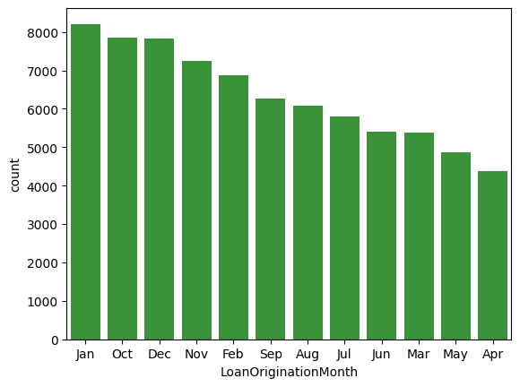

```python
order= loandata.LoanOriginationMonth.value_counts().index
base_color = sns.color_palette()[2]

sns.countplot(data= loandata, x= 'LoanOriginationMonth', order= order, color=base_color);
```

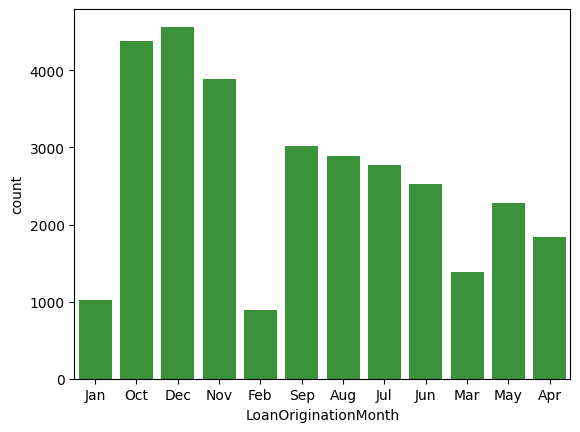

```python
order= loandata.LoanOriginationMonth.value_counts().index
base_color = sns.color_palette()[2]

sns.countplot(data= loandata[loandata.LoanOriginationYear== 2013], x= 'LoanOriginationMonth', order= order, color=base_color);
```

2013 recorded the most loans with December 2013 recording the most loans. Whereas, over the years, January recorded the most loans.

## Bivariate Exploration

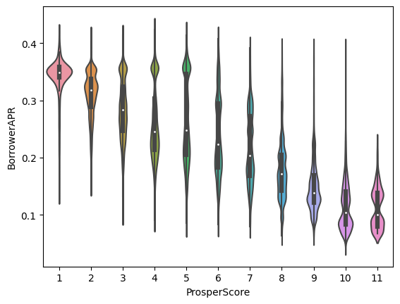

```python
sns.violinplot(data=loandata, x='ProsperScore', y='BorrowerAPR');
```

The ProsperScore and BorrowerAPR are negatively correlated. The lower ProsperScore had higher BorrowerAPR.

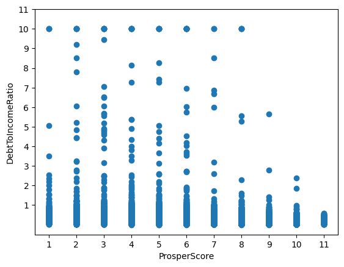

```python
plt.scatter(data=loandata, y='DebtToIncomeRatio', x='ProsperScore');
plt.yticks(np.arange(1,12,1));
plt.xticks(np.arange(1,12,1));
plt.xlabel('ProsperScore');
plt.ylabel('DebtToIncomeRatio');
```

### Observation

The higher values of Prosperscore had lower debt to income ratios compared to other values

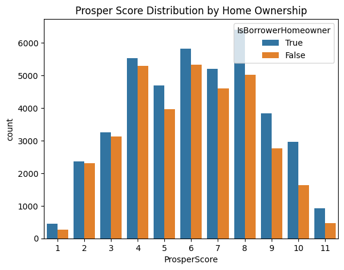

```python
sns.countplot(data=loandata, x= 'ProsperScore', hue='IsBorrowerHomeowner')
plt.title('Prosper Score Distribution by Home Ownership')
```

### Observation

IsBorrowerHomeOwner did not have an announced effect on getting a loan but more Home owners appeared towards the higher Prosper scores than those that did not.

```python
numeric_vars = ['Term','BorrowerAPR','BorrowerRate','ListingCategory','EmploymentStatus','LoanOriginalAmount',
                'StatedMonthlyIncome', 'DebtToIncomeRatio']
categoric_vars = ['LoanStatus','ProsperScore','EmploymentStatus', 'IsBorrowerHomeowner','IncomeRange','LoanOriginationMonth']
```

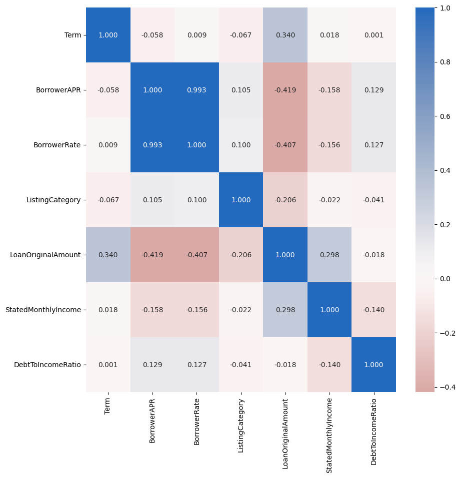

```python
# correlation plot
plt.figure(figsize = [10, 10])
sns.heatmap(loandata[numeric_vars].corr(), annot = True, fmt = '.3f',
           cmap = 'vlag_r', center = 0)
plt.show()
```

### Observation

- loan original amount is positively correlated to Term and negatively correlated to Borrower rate and APR
- DebtToIncomeRatio is positively correlated to Borrower rate and APR

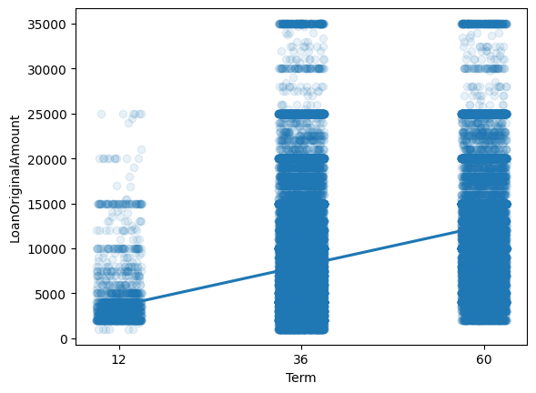

```python
sns.regplot(data=loandata, y= 'LoanOriginalAmount',x= 'Term', scatter_kws={'alpha':0.1}, x_jitter=3);
plt.xticks([12,36,60]);
```

```
loandata.shape= (76224, 22)
loan_samp.shape= (1000, 22)
```

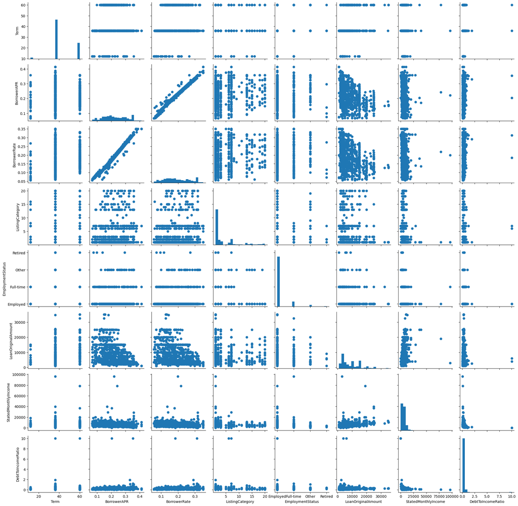

```python
# plot matrix so that plots are clearer and they render faster
print("loandata.shape=",loandata.shape)
loan_samp = loandata.sample(n=1000, replace = False)
print("loan_samp.shape=",loan_samp.shape)
plt.figure(figsize=[12,12]);
g = sns.PairGrid(data = loan_samp, vars = numeric_vars);
g = g.map_diag(plt.hist, bins = 20);
g.map_offdiag(plt.scatter);
```

## Multivariate Exploration

I want to explore on my variables of main interest to see more relationships

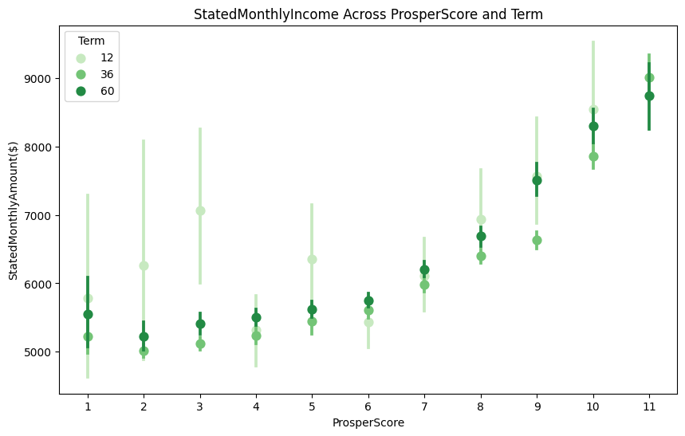

```python
plt.figure(figsize = [10,6])
sns.pointplot(data = loandata, x = 'ProsperScore', y = 'StatedMonthlyIncome', hue = 'Term',
           palette = 'Greens', linestyles = '')
plt.title('StatedMonthlyIncome Across ProsperScore and Term')
plt.ylabel('StatedMonthlyAmount($)')
plt.xlabel('ProsperScore')
plt.show()
```

### Observation

People with high stated monthly income had high prosper scores and had the highest ratio of long term loans

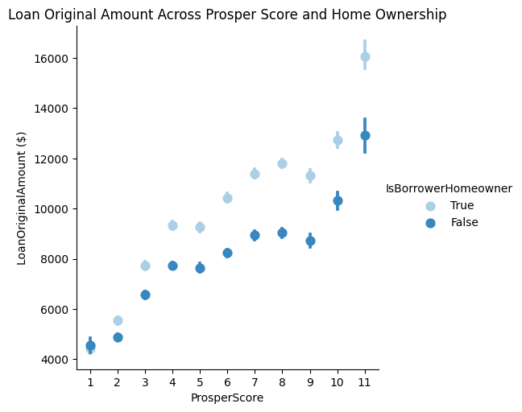

```python
plt.figure(figsize = [10,6]);
sns.catplot(data = loandata, x = 'ProsperScore', y = 'LoanOriginalAmount',kind='point', hue = 'IsBorrowerHomeowner',palette = 'Blues',join=False);
plt.title('Loan Original Amount Across Prosper Score and Home Ownership');
plt.ylabel('LoanOriginalAmount ($)');
plt.xlabel('ProsperScore');
plt.show();
```

### Observation

A combination of a very high Prosper score and being a home owner guarantees access to high loan amounts.